# Ambient sound levels

Rick O. Gilmore

2017-01-17

## Preliminaries

Data were stored in .csv text or as .zip files on Adolph lab server within participant-specific folders. These are now copied to a local set of directories:

`analysis/data/csv`

File name conventions were largely consistent, but not entirely so:

- `S#10_DecibelData.csv` is the standard
- `S#13_Decibel Data.csv` and `S#14_Decibel Data.csv` also occur.

**I manually changed the names of S#13 and S#14 to comply with pattern.**

There is sometimes a header row with `Date,Time,Average,Peak`, but not always.

In some files, the Date, Time, Average, and Peak values are separated by commas, but in some files the Date and Time fields are concatenated. The Average and Peak values are usually comma-separated.

The last row has summary data in some files, but not all:

`Averages: 59.8418 66.358`

Most files have approximately 20,000 rows.

## Data cleaning strategy

1. Import each file individually
2. Clean file
   - Add header row if it doesn’t exist.
   - Determine how to parse Date and Time if they are concatenated.
   - Delete final row of average data since this can be computed.
3. Save new cleaned, comma-delimited file. Consider renaming to avoid # character and make S numbers have equal characters.
4. Once 1-3 have been done, then write import script with these commands as the core:
   - `db.file.list <- list.files(path = "analysis/data/csv", pattern = "\\.csv$", full.names = TRUE)`
   - `db.df.list <- lapply(db.file.list, read.csv)`
5. Suggest that target data file should include participant ID in a form that can be merged/linked with other data files.

## Going forward

1. Create data export procedure from device that does *not* rely on manual file naming.
2. Ensure header rows are created.
3. Ensure that Date and Time are comma-separated.

## Data cleaning notes

It was easier to change the filenames manually, and then I ran the following substitution in the files with concatentated `Date` and `Time` fields:

search.pattern=“^([0-9]{4}):([0-9]{2}):([0-9]{2}):” replacement.pattern=“$1-$2-$3,”

This changes the colons separating the date elements into dashes, and replaces the separating colon between `Date` and `Time` with a comma.

Here’s a function to add a more informative subject ID to the file and save it:

```r
Add.subnum.to.db.file <- function(fn) {
  sub.num <- paste("nyu", substr(fn, 2, 3), sep="_")

  in.dat <- read.csv(fn, header = TRUE)

  out.dat <- data.frame(sub.num = sub.num,
                        date = in.dat$Date,
                        time = in.dat$Time,
                        db.avg = in.dat$Average,
                        db.peak = in.dat$Peak)

  write.csv(x = out.dat,
            file = paste(sub.num, "ambient_db.csv", sep = "_"),
            row.names = FALSE)
}
```

I ran this across the list of `Snn_DecibelData.csv` files and found some problem sith `S10*`. I just deleted it for now.

Then, I deleted the last row from all data files as follows:

```r
Remove.last.db.row.if.avg <- function(fn) {
  df <- read.csv(fn)
  if ("Average Decibels" %in% df$date) {
    df <- df[1:(dim(df)[1]-1),]
  }
  write.csv(x = df, file = fn, row.names = FALSE)
  df
}

db.file.list <- list.files(path = "analysis/data/csv", pattern = "^nyu", full.names = TRUE)
```

## Importing data and creating aggregate data frame

```r
db.file.list <- list.files(path = "analysis/data/csv", pattern = "^nyu", full.names = TRUE)

db.df.list <- lapply(db.file.list, read.csv)

db.aggregate.df <- Reduce(function(x, y) merge(x, y, all=TRUE),
                          db.df.list)
```

Here are some simple plots, first of average sound levels.

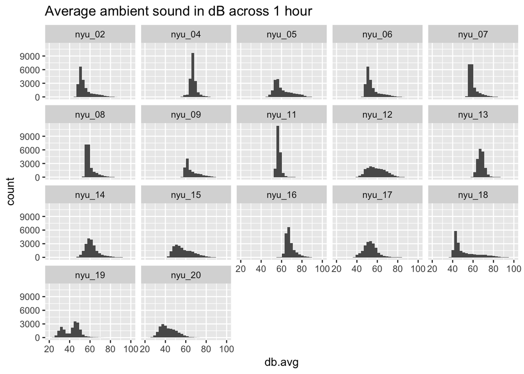

```r
library(ggplot2)

ggplot(data = db.aggregate.df, aes(x=db.avg)) +
  geom_histogram() +
  facet_wrap(facets = c("sub.num")) +
  ggtitle("Average ambient sound in dB across 1 hour")
```

And here, peak sound levels.

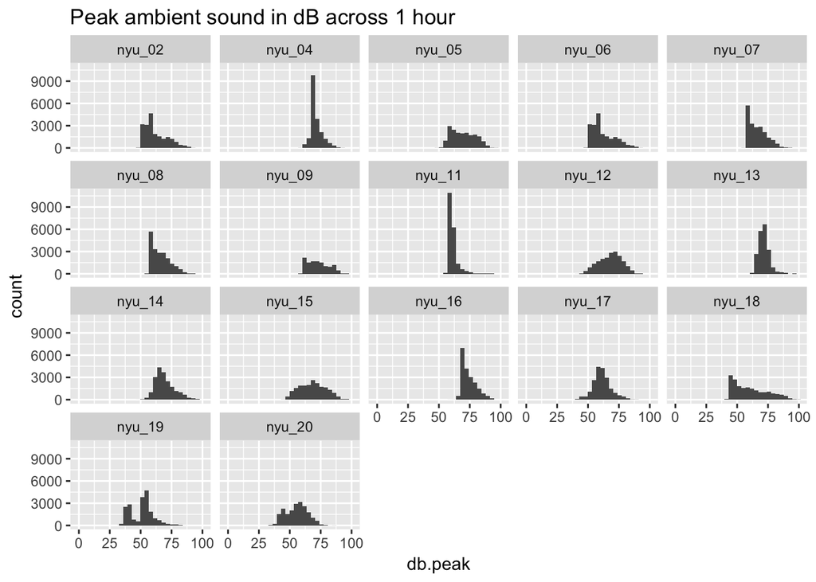

```r
library(ggplot2)

ggplot(data = db.aggregate.df, aes(x=db.peak)) +
  geom_histogram() +
  facet_wrap(facets = c("sub.num")) +
  ggtitle("Peak ambient sound in dB across 1 hour")
```